# Rmarkdown_Document_Method_and_Results

Haizhen_H.

4/30/2022

```r
library(tidyverse)
library(reshape2)
```

# Background

According to the Federal Bureau of Investigation and the Bureau of Justice Statistics,

the crime rate in the United States has declined significantly year by year since the 1990s.

Those crime included homicide, rape, robbery, burglary and etc.

My data analysis aimed to examine United States crime rate data to verify if it is true that the crime rate is actually decreasing.

# Method

The dataset I chose is named United States Crime Rate that I found from Kaggle which is an online platform for Data Sciences and Data Analysis.

The first column is the crime type which include violent, murder, rape and etc.They are strings The second column is the identify number which is the primary key to represent the crime type. They are integer. The rest of the columns are the year from 1995 to 2018. And they are all integer.

I analyzed my dataset by using a linear model that I aggregate the frequency of crime by year. And I tested if the total crime frequency was related to year.

My hypothesis is there exist a linear relationship between year and crime rate that as year increase, the crime rate will be decrease.

The best visualization to show the relationship is the scatter plot with a line plot of linear model.

### Participants or Observation

```r
load("df.RData")
df
```

```
## # A tibble: 9 x 26
##   `Crime Type`    ID  `1995`  `1996`  `1997`  `1998` `1999` `2000` `2001` `2002`
##   <chr>        <dbl>   <dbl>   <dbl>   <dbl>   <dbl>  <dbl>  <dbl>  <dbl>  <dbl>
## 1 Violent          1  1.80e6  1.69e6  1.64e6  1.53e6 1.43e6 1.43e6 1.44e6 1.42e6
## 2 Murder           2  2.16e4  1.96e4  1.82e4  1.70e4 1.55e4 1.56e4 1.60e4 1.62e4
## 3 Rape             3  9.75e3  9.63e4  9.62e4  9.31e4 8.94e4 9.02e4 9.09e4 9.52e4
## 4 Robbery          4  9.75e3  9.63e4  9.62e4  9.31e4 8.94e4 9.02e4 9.09e4 9.52e4
## 5 Assault          5  5.81e5  5.36e5  4.99e5  4.47e5 4.09e5 4.08e5 4.24e5 4.21e5
## 6 Property         6  1.10e6  1.04e6  1.02e6  9.77e5 9.12e4 9.12e5 9.09e5 8.91e5
## 7 Burglary         7  1.21e7  1.18e7  1.16e7  1.10e7 1.02e7 1.02e7 1.04e7 1.05e7
## 8 Larceny          8  2.59e6  2.51e6  2.46e6  2.33e6 2.10e6 2.05e6 2.12e6 2.15e6
## 9 MV Theft         9  8.00e6  7.90e6  7.74e6  7.38e6 6.96e6 6.97e6 7.09e6 7.06e6
## # ... with 16 more variables: 2003 <dbl>, 2004 <dbl>, 2005 <dbl>, 2006 <dbl>,
## #   2007 <dbl>, 2008 <dbl>, 2009 <dbl>, 2010 <dbl>, 2011 <dbl>, 2012 <dbl>,
## #   2013 <dbl>, 2014 <dbl>, 2015 <dbl>, 2016 <dbl>, 2017 <dbl>, 2018 <dbl>
```

### Procudure

```r
cleardf <- df %>%
  na.omit()%>%
  melt(id = c("Crime Type","ID")) %>%
  rename(Crime_Type = `Crime Type`, Year = variable, Frequency  = value)%>%
  mutate(Year = as.numeric(as.character(Year))) %>%
  group_by(Year) %>%
  mutate(Total_freq = sum(Frequency)) %>%
  select(Year, Total_freq) %>%
  unique()
cleardf
```

```
## # A tibble: 24 x 2
## # Groups:   Year [24]
##     Year Total_freq
##    <dbl>      <dbl>
##  1  1995   26175037
##  2  1996   25689740
##  3  1997   25131106
##  4  1998   23821791
##  5  1999   21385526
##  6  2000   22146316
##  7  2001   22615810
##  8  2002   22606497
##  9  2003   21712606
## 10  2004   21854863
## # ... with 14 more rows
```

```r
lin_model <- lm(cleardf$Total_freq~cleardf$Year)
```

My first step is to remove the NA from my dataset to make sure integrity, correctness and completeness. Next, I used the melt function from the reshape2 package to transform my dataset to long format and rename the columns. Because the Year is a factor column so I converted this column into character then numeric. Finally, I group the dataset by Year and calculate the total crime frequency of all crime types. I removed the duplicated rows to ensure uniqueness. The completed dataset have Year and Total_freq columns.

# Result

```r
summary(lin_model)
```

```
##
## Call:
## lm(formula = cleardf$Total_freq ~ cleardf$Year)
##
## Residuals:
##      Min       1Q   Median       3Q      Max
## -2353426  -302433     8287   608872   993046
##
## Coefficients:
##               Estimate Std. Error t value Pr(>|t|)
## (Intercept)  744898108   48995363   15.20 3.74e-13 ***
## cleardf$Year   -360760      24418  -14.77 6.66e-13 ***
## ---
## Signif. codes:  0 '***' 0.001 '**' 0.01 '*' 0.05 '.' 0.1 ' ' 1
##
## Residual standard error: 828100 on 22 degrees of freedom
## Multiple R-squared:  0.9084, Adjusted R-squared:  0.9043
## F-statistic: 218.3 on 1 and 22 DF,  p-value: 6.662e-13
```

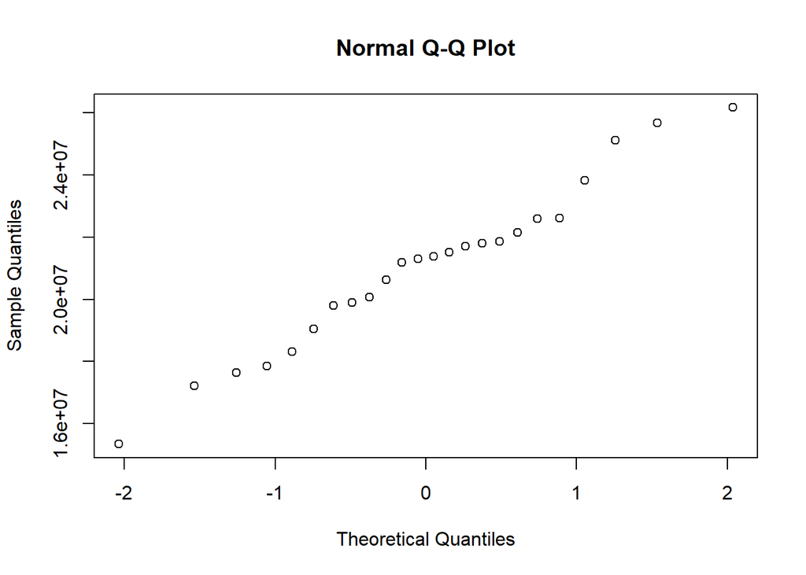

```r
qqnorm(cleardf$Total_freq)
```

The relevant statistics I was applied is Linear Regression.

This analysis appropriate to my dataset because I want to analyze if there exist a tendency of crime and year that whether the total crime rate will change if the time change.

Linear models assume that the relationship between variables is linear, so met the Linearity assumption. Based on the observation from qqnorm plot, my dataset met the normality.

Adjusted R-squared is 0.9043 which means Year can interpret 90.43% of this model

Therefore the outcome of the linear model indicated there existed a relationship between Year and Total crime frequency of that year.

# Discussion

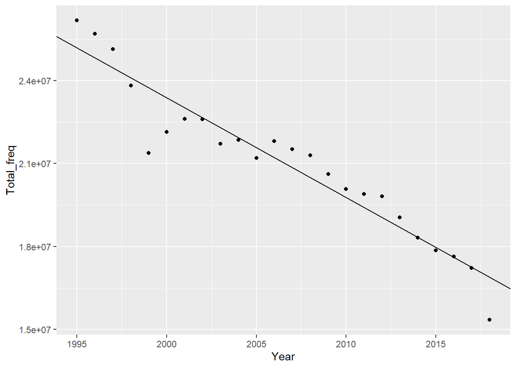

```r
cleardf %>%
  ggplot(aes(x= Year, y = Total_freq))+
  geom_point()+
  geom_abline(slope = coef(lin_model)[2],intercept = coef(lin_model)[1])
```

Intercept is 744898108 which mean there are 744898108 crime cases happened in the initial year(0 year) for the model.

But it doesn’t make sense if we just interpret it separately because the year of dataset is between 1995 - 2018

And the slope of the linear model is -360,760 which means there are an average decreased 360,760 crime cases year by year from 1995s to 2018s

### Limitation

My dataset only included data of Year, Crime type, and Crime frequency.

And Crime frequency might effect by many other factors than just Year. Like location, income or age, etc.

Even though Year is strongly correlated with Crime frequency, the lack of other factors is still a limitation of my data, and we need to keep it in mind when we consider this analysis.

### Conclusion

Based on my data analysis, we can conclude that there has a tendency between year and crime rate. As increase 1 year, the total crime frequency will decrease 360,760. Two variables are strongly correlated with each other, and result of the linear model proved my hypothesis is correct.

# References

**Crime Rate in the US from Kaggle**

[link](https://www.kaggle.com/datasets/mathurinache/crimerateintheus)